# Bellabeat Case Study with R

By Sadia Tanjim

### Introduction

Welcome to my Bellabeat data analysis case study. In this case study, I will perform real-world tasks of a data analyst. In order to answer some key business questions, I will follow the steps of the data analysis process: ask, prepare, process, analyze, share, and act.

### About the Bellabeat Company

Bellabeat, is a high-tech manufacturer of health-focused products for women. Bellabeat is a successful small company, and they have the potential to become a larger player in the global smart device market. Urška Sršen and Sando Mur founded Bellabeat, a high-tech company that manufactures health-focused smart products. Collecting data on activity, sleep, stress, and reproductive health has allowed Bellabeat to empower women with knowledge about their own health and habits. Since it was founded in 2013, Bellabeat has grown rapidly and quickly positioned itself as a tech-driven wellness company for women.

### Scenario of the Study

In this study, I will focus on one of Bellabeat’s products and analyze smart device data to gain insight into how consumers are using their smart devices. The insights will then help guide marketing strategy for the company.

### Questions for the Analysis (Ask phase)

In this phase, I tried to better understand the data and the problem I’m trying to solve. And to do that, I had to do more research and ask more questions.

- **What are some trends in smart device usage? How could these trends apply to Bellabeat customers? How could these trends help influence Bellabeat marketing strategy?** So first, the company need to better target their marketing efforts into their customer’s needs based on their usage of their fitness smart devices. And then, make high-level recommendations for how these trends can inform Bellabeat marketing strategy.
- **Who are the main stakeholders?** The main stakeholders are Urška Sršen, Bellabeat’s co-founder and Chief Creative Officer; Sando Mur, Mathematician and Bellabeat’s co founder; And also, we need to think about and work with the rest of the Bellabeat marketing analytics team.

### Business Task

Now, after getting answers to all of my questions (during the ask phase), I’m able to define clearly the business task which is: *Analyze customers’ use of an existing competitor to identify potential opportunities for growth and recommendations for the Bellabeat marketing strategy based on trends in smart device usage.*

### Preparing the Data (Prepare Phase)

#### Description of the data source

The dataset is generated by respondents to a distributed survey via Amazon Mechanical Turk between 03.12.2016 and 05.12.2016 and include 18 CSV files. Thirty eligible Fitbit users consented to the submission of personal tracker data, including minute-level output for physical activity, heart rate, and sleep monitoring. Variation between output represents use of different types of Fitbit trackers and individual tracking behaviors / preferences.

The key assumption of using this dataset is that the Fitbit users are representative users of Leaf. However, this is not necessarily the case. The target users of Bellabeat are women, while Fitbit users includes both genders. In this way, the data collected is not completely applicable to Bellabeat users. Also, the sample size is too small to make a determining decision.

However, overall, the dataset is a good data source because it is:

- Reliable: Accurate, complete, unbiased information that is fit for use
- Original: Not through a second or third party source
- Comprehensive: Contain all critical information needed to answer the questions
- Current: Current and relevant to the task at hand
- Cited: Explicitly cited and credible

#### Downloading the data

Here is the link to download the dataset:

- FitBit Fitness Tracker Data : https://www.kaggle.com/arashnic/fitbit

#### Installing packages

```r
# Installing packages :
install.packages("tidyverse")
install.packages("lubridate")
install.packages("dplyr")
install.packages("ggplot2")
install.packages("tidyr")
install.packages("here")
install.packages("skimr")
install.packages("janitor")
```

#### Loading packages

Now, I’m going to load these packages. And I’m using in my R code (valid for RStudio only) the options message=FALSE and warning=FALSE, to save space. And to prevent printing of the execution of the R code generated and the warning messages.

```r
# Loading packages :

library(tidyverse)
library(lubridate)
library(dplyr)
library(ggplot2)
library(tidyr)
library(here)
library(skimr)
library(janitor)
```

#### Importing dataset

Now, I’m going to Import all dataset.

```r
#for PDF
knitr::opts_chunk$set(cache = TRUE)
```

```r
load("Fitabase Data 4.12.16-5.12.16/Bellabeat.RData")
```

```r
#for Word
#load("~/filename.RData")
```

Then VIEW, CLEAN, FORMAT, and ORGANIZE the data. After reviewing all the dataset, I decided to make some assumptions and work only with these data for my analysis:

- **dailyActivity_merged.csv**

```r
# Importing Activity dataset :

Activity <- read.csv("Fitabase Data 4.12.16-5.12.16/dailyActivity_merged.csv")
head(Activity)
colnames(Activity)
str(Activity)
```

- **dailyCalories_merged.csv**

```r
# Importing Calories dataset !
Calories <- read.csv("Fitabase Data 4.12.16-5.12.16/dailyCalories_merged.csv")
head(Calories)
colnames(Calories)
str(Calories)
```

- **dailyIntensities_merged.csv**

```r
# Importing Intensities dataset !
Intensities <- read.csv("Fitabase Data 4.12.16-5.12.16/dailyIntensities_merged.csv")
head(Intensities)
colnames(Intensities)
str(Intensities)
```

- **heartrate_seconds_merged.csv**

```r
# Importing Heartrate dataset !
Heartrate <- read.csv("Fitabase Data 4.12.16-5.12.16/heartrate_seconds_merged.csv")
head(Heartrate)
colnames(Heartrate)
str(Heartrate)
```

- **sleepDay_merged.csv**

```r
# Importing Sleep dataset !
Sleep <- read.csv("Fitabase Data 4.12.16-5.12.16/sleepDay_merged.csv")
head(Sleep)
colnames(Sleep)
str(Sleep)
```

- **weightLogInfo_merged.csv**

```r
# Importing Weight dataset !
Weight <- read.csv("Fitabase Data 4.12.16-5.12.16/weightLogInfo_merged.csv")
head(Weight)
colnames(Weight)
str(Weight)
```

### Cleaning the dataset (Process Phase)

#### Basic cleaning :

Now, I’m going to Process, Clean and Organize the dataset for analysis. I used functions like glimpse(), skim_without_charts to quickly review the data. I also clean the names of the data using clean_names().

And here some cleaning steps I did with the data :

- For Dataset (Activity, Calories and Intensities): For the data cleaning steps, I did NOT FOUND in this data (Spelling errors, Misfiled values, Missing values, Extra and blank space, no duplicated found). For Data types, some data were converted to numeric and Dates columns will be converted to date type.
- For Sleep data : 3 duplicates were found and removed.
- For Weight data : Too many missing values were found in one column. And I decided to remove that column.

**Getting to know data and clean column names**

```r
# Activity
skim_without_charts(Activity)
Activity_new <- Activity
clean_names(Activity_new)
```

```r
# Calories
skim_without_charts(Calories)
Calories_new <- Calories
clean_names(Calories_new)
```

```r
# Intensities
skim_without_charts(Intensities)
Intensities_new <- Intensities
clean_names(Intensities_new)
```

```r
# Heartrate
skim_without_charts(Heartrate)
Heartrate_new <- Heartrate
clean_names(Heartrate_new)
```

```r
# Sleep
skim_without_charts(Sleep)
Sleep_new <- Sleep
clean_names(Sleep_new)
view(Sleep_new)
```

```r
# Weight
skim_without_charts(Weight)
Weight_new <- Weight
clean_names(Weight_new)
```

**Findings duplicates and remove duplicates**

```r
# Activity_new
duplicated(Activity_new)

# Calories_new
duplicated(Calories_new)

# Intensities_new
duplicated(Intensities_new)

# Heartrate_new
duplicated(Heartrate_new)

# Sleep_new
duplicated(Sleep_new) # found 3 duplicate
Sleep_new <- unique(Sleep_new) # remove duplicates
duplicated(Sleep_new)

# Weight_new
duplicated(Weight_new)
```

**Count the number of NA values and remove NA values**

```r
# Activity_new
sum(is.na(Activity_new))

# Calories_new
sum(is.na(Calories_new))

# Intensities_new
sum(is.na(Intensities_new))

# Heartrate_new
sum(is.na(Heartrate_new))

# Sleep_new
sum(is.na(Sleep_new))

# Weight_new
sum(is.na(Weight_new))  # Found 65 values
Weight_new <- select(Weight_new, -Fat) #remove the column
view(Weight_new)
```

#### Organizing data :

**Fixing formatting**

I spotted some problems with the time stamp data. So before analysis, I need to convert it to date time format and split to date and time.

```r
library(ggplot2)
# For Activity_new

# Convert character data to date and time
Activity_new$ActivityDate=as.POSIXct(Activity_new$ActivityDate, format="%m/%d/%Y", tz=Sys.timezone())

# setting format to specify the style
Activity_new$date <- format(Activity_new$ActivityDate, format = "%m/%d/%y")

# convert column to date class using as.date method/ save date in date format
Activity_new$ActivityDate=as.Date(Activity_new$ActivityDate, format="%m/%d/%Y", tz=Sys.timezone())

# convert column to date class using as.date method and split to date
Activity_new$date=as.Date(Activity_new$date, format="%m/%d/%Y")
View(Activity_new)
```

```r
# For Intensities_new

Intensities_new$ActivityDay=as.Date(Intensities_new$ActivityDay, format="%m/%d/%Y", tz=Sys.timezone())
View(Intensities_new)
```

```r
# For Sleep_new

Sleep_new$SleepDay=as.POSIXct(Sleep_new$SleepDay, format="%m/%d/%Y %I:%M:%S %p", tz=Sys.timezone())
Sleep_new$date <- format(Sleep_new$SleepDay, format = "%m/%d/%y")
Sleep_new$date=as.Date(Sleep_new$date, "% m/% d/% y")
View(Sleep_new)
```

**Changing the Data type**

Change the data type of Id (numeric) to Character

```r
# Activity_new
Activity_new$Id = as.character(Activity_new$Id)
str(Activity_new)

# Calories_new
Calories_new$Id = as.character(Calories_new$Id)
str(Calories_new)

# Intensities_new
Intensities_new$Id = as.character(Intensities_new$Id)
str(Intensities_new)

#Heartrate_new
Heartrate_new$Id = as.character(Heartrate_new$Id)
str(Heartrate_new)

# Sleep_new
Sleep_new$Id = as.character(Sleep_new$Id)
str(Sleep_new)

# Weight_new
Weight_new$Id = as.character(Weight_new$Id)
str(Weight_new)
```

**Checking the Id length**

Since the function is not showing any errors, all ID lengths = 10

```r
# Activity_new
id_lens <- nchar(Activity_new$Id)  # Count Id lengths
id_lens_bool <- id_lens == 10      # True/False check if id == 10 or not
stopifnot(id_lens_bool)         # This function will show Error if not all TRUE

# Since the function is not showing any errors, all ID lengths = 10

# Calories_new
id_lens <- nchar(Calories_new$Id)
id_lens_bool <- id_lens == 10
stopifnot(id_lens_bool)

# Intensities_new
id_lens <- nchar(Intensities_new$Id)
id_lens_bool <- id_lens == 10
stopifnot(id_lens_bool)

# Heartrate_new
id_lens <- nchar(Heartrate_new$Id)
id_lens_bool <- id_lens == 10
stopifnot(id_lens_bool)

# Sleep_new
id_lens <- nchar(Sleep_new$Id)
id_lens_bool <- id_lens == 10
stopifnot(id_lens_bool)

# Weight_new
id_lens <- nchar(Weight_new$Id)
id_lens_bool <- id_lens == 10
stopifnot(id_lens_bool)
```

### Summarizing the dataset (Analyze Phase)

Now that all the data is stored appropriately and has been prepared for analysis, I can start putting it to work.

**Let’s look at the total number of participants in each data sets:**

**How many observations are there in each data frame?**

So I will focus on these datasets for my analysis: Activity, Calories, Intensities and Sleep.

**Here are some quick summary statistics about each data frame.**

- For the Activity_new data frame :

```r
# Activity_new
Activity_new %>%
  select(TotalSteps,
         TotalDistance,
         VeryActiveMinutes,
         SedentaryMinutes, Calories) %>%
  summary()
```

- For the Calories_new data frame :

```r
# Calories_new
Calories_new %>%
  select(Calories) %>%
  summary()
```

- For the Intensities_new data frame :

```r
# Intensities_new
Intensities_new %>%
  select(VeryActiveMinutes,
         FairlyActiveMinutes,
         LightlyActiveMinutes,
         SedentaryMinutes) %>%
  summary()
```

- For the Sleep_new data frame :

```r
# Sleep_new
Sleep_new %>%
  select(TotalSleepRecords,
         TotalMinutesAsleep,
         TotalTimeInBed) %>%
  summary()
```

- For the Weight_new data frame :

```r
# Weight_new
Weight_new %>%
  select(WeightKg, BMI) %>%
  summary()
```

- Average total steps per day (which is 7638) is a little bit less than recommended by the CDC (8000).
- The average sedentary time is very high (more than 16 hours).
- Average Calorie is little bit higher . Recommended daily calorie intakes in the US are around 2500 per day for men and 2000 for women.
- The majority of the participants are lightly active with a high sedentary time.
- Participants spend more time in bed than total minutes asleep, on average.

### Data Visualization (Share Phase)

Once I have completed my analysis, create my data visualizations. The visualizations should clearly communicate high-level insights and recommendations.

#### Plotting few explorations :

- *For Activity_new*

##### Relationship between Steps and Sedentary time

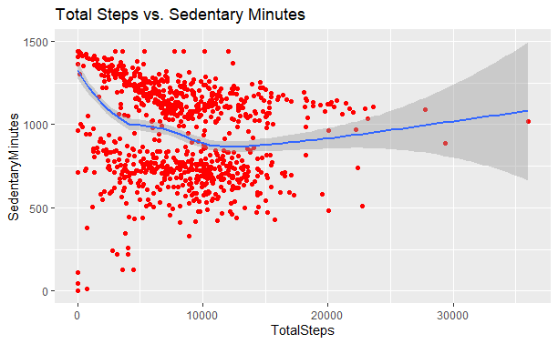

```r
require(ggplot2)
ggplot(data=Activity_new) +
  geom_jitter(mapping=aes(x=TotalSteps, y=SedentaryMinutes),color="red") +
  geom_smooth(mapping=aes(x=TotalSteps, y=SedentaryMinutes), formula = 'y ~ x', method ='loess') +
  labs(title="Total Steps vs. Sedentary Minutes")
```

We can see a negative correlation between Total Steps and Sedentary Minutes. It is evident that people logging more sedentary time are less likely to take part in physical activity like walking.

##### Correlation test

```r
corr_01 <- cor.test(Activity_new$TotalSteps, Activity_new$SedentaryMinutes,
                      method = "pearson")

corr_01 # (-0.3274835)
```

```
    Pearson's product-moment correlation

data:  Activity_new$TotalSteps and Activity_new$SedentaryMinutes
t = -10.615, df = 938, p-value < 2.2e-16
alternative hypothesis: true correlation is not equal to 0
95 percent confidence interval:
 -0.3833971 -0.2691782
sample estimates:
       cor
-0.3274835
```

I can see here a negative correlation between Steps and Sedentary time.

##### Relationship between Steps and Calories

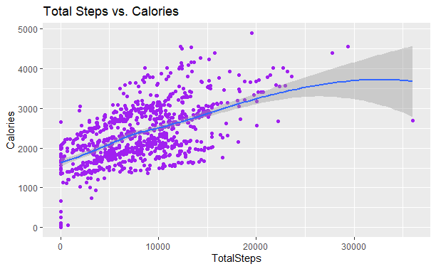

```r
ggplot(data=Activity_new) +
  geom_jitter(mapping=aes(x=TotalSteps, y=Calories), color='purple') +
  geom_smooth(mapping=aes(x=TotalSteps, y=Calories), formula = 'y ~ x', method ='loess') +
  labs(title="Total Steps vs. Calories")
```

We can see a positive correlation between total steps and calories burned. It is evident that people logging in more steps are physically more active hence they are able to burn more calories everyday.

##### Correlation test

```r
corr_02 <- cor.test(Activity_new$TotalSteps, Activity_new$Calories,
                      method = "pearson")

corr_02 # (0.5915681)
```

```
    Pearson's product-moment correlation

data:  Activity_new$TotalSteps and Activity_new$Calories
t = 22.472, df = 938, p-value < 2.2e-16
alternative hypothesis: true correlation is not equal to 0
95 percent confidence interval:
 0.5483688 0.6316184
sample estimates:
      cor
0.5915681
```

positive correlation between Total Steps and Calories.

##### Time of different Activity types

```r
# run this chunk if '%>%' is not found

install.packages("magrittr") # package installations are only needed the first time you use it
install.packages("dplyr")    # alternative installation of the %>%
library(magrittr) # needs to be run every time you start R and want to use %>%
library(dplyr)    # alternatively, this also loads %>%
```

```r
library(dplyr)
df <- Activity_new %>%
  select(ActivityDate,
         VeryActiveMinutes,
         FairlyActiveMinutes,
         LightlyActiveMinutes,
         SedentaryMinutes)
head(df)
```

```r
df$WeekDay <- weekdays(df$ActivityDate)
df$WeekDay <- factor(df$WeekDay, levels = c("Monday", "Tuesday",
                                                 "Wednesday", "Thursday", "Friday",
                                                 "Saturday", "Sunday"))

df[order(df$WeekDay), ]


df$VeryActiveHours <- (df$VeryActiveMinutes)/60
df$FairlyActiveHours <- (df$FairlyActiveMinutes)/60
df$LightlyActiveHours <- (df$LightlyActiveMinutes)/60
df$SedentaryHours <- (df$SedentaryMinutes)/60


df05 <- df %>%
  select(WeekDay, VeryActiveHours, FairlyActiveHours,
         LightlyActiveHours, SedentaryHours) %>%
  group_by(WeekDay) %>%
  summarize(sum_SedentaryHours = sum(SedentaryHours),
            sum_VeryActiveHours = sum(VeryActiveHours),
            sum_FairlyActiveHours = sum(FairlyActiveHours),
            sum_LightlyActiveHours = sum(LightlyActiveHours))



head(df05)
```

```r
library(tidyr)
library(ggplot2)
```

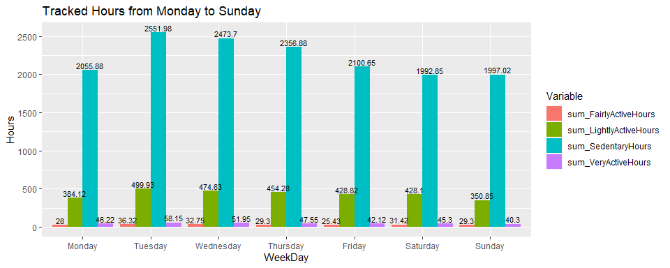

```r
ggplot(data = df05 %>% gather(Variable, Hours, -WeekDay),
       aes(x = WeekDay, y = Hours, fill = Variable)) +
  geom_bar(stat = 'identity', position ='dodge') +
  geom_text(aes(label=round(Hours, digits = 2)),
            position = position_dodge(width = 0.9), vjust=-0.25, size=3)+
  scale_y_continuous(breaks = scales :: pretty_breaks(n=10)) +
  labs(title="Tracked Hours from Monday to Sunday")
```

The average user spends a lot of sedentary time.The number of sedentary hours is lower during the weekends and at the start of the week. However, it sees an increasing trend during the middle of the week for example during Tuesday/Wednesday/Thursday. This might be due to work stress or users simply forgetting to workout.The users active time is also not consistent throughout the week. Bellabeat users might be encouraged to track their active/sedentary hours throughout the the week and reminded to take some time to relieve stress and encourage some light activity mid-week.

##### Relationship between Minutes Asleep and Time in Bed

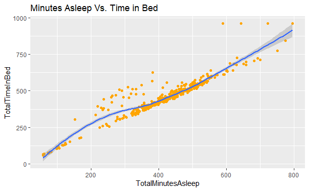

```r
ggplot(data = Sleep_new) +
  geom_jitter(mapping=aes(x=TotalMinutesAsleep, y=TotalTimeInBed), color="orange") +
  geom_smooth(mapping=aes(x=TotalMinutesAsleep, y=TotalTimeInBed), method='loess', formula='y ~ x') +
  labs(title="Minutes Asleep Vs. Time in Bed")
```

Participants spend more time in bed than actual time asleep. Sleep quality and sleeping habits are not ideal.

##### Correlation test

```r
corr_03 <- cor.test(Sleep_new$TotalMinutesAsleep, Sleep_new$TotalTimeInBed,
                       method = "pearson")

corr_03 # (0.9304224
```

```
    Pearson's product-moment correlation

data:  Sleep_new$TotalMinutesAsleep and Sleep_new$TotalTimeInBed
t = 51.28, df = 408, p-value < 2.2e-16
alternative hypothesis: true correlation is not equal to 0
95 percent confidence interval:
 0.9161262 0.9423551
sample estimates:
      cor
0.9304224
```

I can see a strong positive correlation between total minutes asleep and total time in bed.

#### Merging some data :

- *Activity_new and Sleep_new data merging*

I’m going to merge two data sets : Activity and Sleep data on columns Id. Note that there are more participant Ids in the Activity dataset than in the Sleep dataset. So if I use the merge option inner_joint, then I will have the number of participants from the Sleep data set.

```r
Combined_inner <- merge(Activity_new, Sleep_new, by="Id")
n_distinct(Combined_inner$Id)
```

```
[1] 24
```

So for analysis, I will consider using ‘outer_join’ to keep all participants in the in the dataset. And I can do that by adding in my code chunk the extra argument all=TRUE.

```r
Combined_outer <- merge(Activity_new, Sleep_new, by="Id", all = TRUE)
n_distinct(Combined_outer$Id)
```

```
[1] 33
```

```r
# View(Combined_outer)
```

#### Relationship between Calories, Distance and Total Minutes Asleep

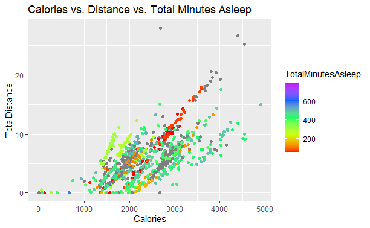

```r
calories_distance_sleep_point <- ggplot(Combined_outer) +
  geom_point(mapping=aes(x=Calories, y=TotalDistance, color=TotalMinutesAsleep)) +
  labs(title="Calories vs. Distance vs. Total Minutes Asleep")

calories_distance_sleep_point + scale_color_gradientn(colours = rainbow(5))
```

Based on this plot, we can determine that even after long distances and calories expended, the average amount of sleep ranges from 6 - 8 hours. There were hits of red and orange, but I do think these were recorded in error. However, it is possible some individuals stayed up most of the night and only slept for a couple hours or they might have only tracked themselves taking short naps.

This plot also illustrates the positive correlation between total distance and calories. In other words, the more distance traveled, the more calories expended.

CDC recommends 7-8 hours of sleep per night. Those who get less than 6.5 hours or 390 minutes of sleep each night might be considered sleep-deprived. We can calculate the total percentage of subjects with less than 390 minutes of sleep per night as follows:

```r
install.packages("scales")
```

```r
df1 = Sleep_new
percent_Asleep <- (sum(df1$TotalMinutesAsleep <= 390) / nrow(Sleep_new))


library(scales)
#library(formattable) # loading package

label_percent()(percent_Asleep)
```

```
[1] "34%"
```

#### Correlation Matric of Activity_new and Sleep_new Variables

```r
data <- Combined_outer
head(data)

# Convert Table to a .csv file
write.csv(data, "C:\\Users\\User\\Desktop\\Portfolio Materials\\Fitbit_Fitness_Tracker_Data_20211222v01\\Activity_and_Sleep.csv", row.names = FALSE)
```

```r
# Load the .csv file
Activity_Sleep_data <- read.csv("C:\\Users\\User\\Desktop\\Portfolio Materials\\Fitbit_Fitness_Tracker_Data_20211222v01\\Activity_and_Sleep.csv")

head(Activity_Sleep_data)
```

```r
#Activity_Sleep_data <- Activity_Sleep_data  %>%
  #select(-LoggedActivitiesDistance,
         #-SedentaryActiveDistance
         #)
```

```r
install.packages("metan")
```

```r
library(metan)
library(dplyr)
```

```r
no_na_Activity_Sleep_data <- na.omit(Activity_Sleep_data)
cor(no_na_Activity_Sleep_data[sapply(no_na_Activity_Sleep_data, is.numeric)])
```

```r
load("Fitabase Data 4.12.16-5.12.16/Bellabeat.RData")
```

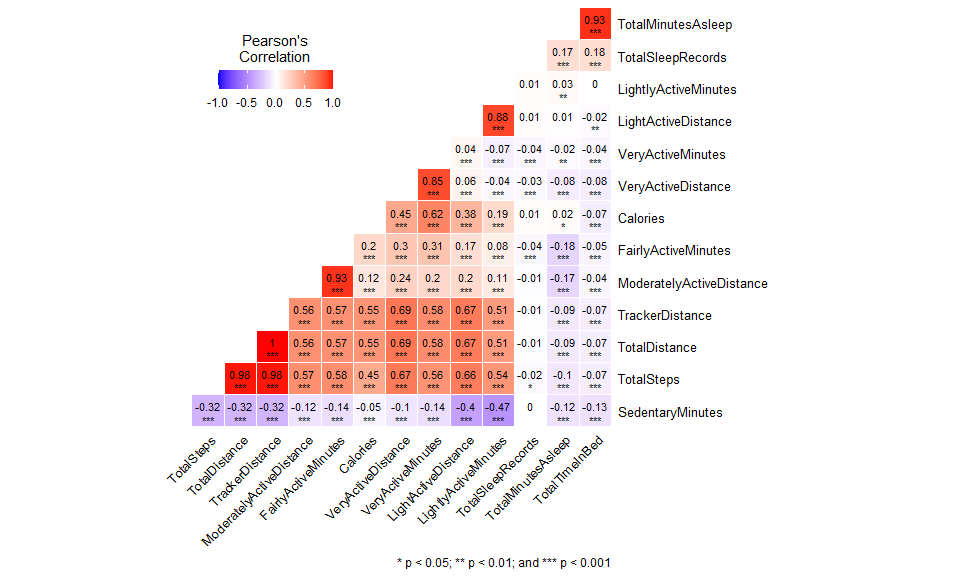

```r
ASd_round <- no_na_Activity_Sleep_data %>% mutate_if(is.numeric,round)
corr <- corr_coef(ASd_round[, -1:-2])
plot(corr)
```

From the above correlation matrix, we can see a strong correlation between the following metrics which are relevant:

- Positive relationship between Calories & Very Active Minutes
- Negative relationship between lightly active minutes & Sedentary Minutes
- Positive relationship between total steps & lightly active minutes/distance, fairly active minutes/distance
- Positive relationship between very active minutes & total distance

We can identify different trends and user behavior relating to the metrics like calories, steps, and distance etc. from the above correlation matrix.

### Conclusions & Recommandations for the Business

So, collecting data on activity, sleep, stress, etc. will allow the company Bellabeat to empower the customers with knowledge about their own health and daily habits. The company Bellabeat is growing rapidly and quickly positioned itself as a tech-driven wellness company for their customers.

**Activity Level:** The majority of participants are lightly active with high sedentary time.

**Step Count:** A significant data point to determine user activity is the number of steps taken each day by a given user. We can see that the average user takes a total of 7638 steps each day.

**Sedentary Time:** It can be seen from the data that the average user spends almost 16 hours a day of Sedentary time which is not a healthy practice.

**Sleep:** Participants spend more time in bed than actual time asleep. Sleep quality and sleeping habits are not ideal.

#### Target Audience :

From the analysis of the dataset, we can identify certain groups of people who could benefit from fitness tracking/lifestyle improvements. These are people with -

- Low level of physical activity
- High level of sedentary time
- Low step count per day and less average distance covered each day
- Low caloric expenditure
- Inadequate amount of sleep/poor sleeping habits, etc.

People with this sort of lifestyle are most likely people with full-time jobs spending a lot of time at the computer or office workers with low levels of physical exercise and a lack of healthy habits, etc. It is recommended that Bellabeat might focus on people with these certain characteristics as a target audience who could benefit from using fitness-tracking smart devices. For example office workers and sedentary workers.

#### Message to the Company :

After a thorough analysis of the dataset, we are able to identify various trends in user behavior relevant to their fitness, health, and lifestyle. These general trends might be useful to make strategic decisions for Bellabeat’s smart devices.

[output not shown]

#### Recommendations to the Bellabeat Marketing team :

In light of the above findings and recommendations, the Bellabeat marketing team might be able to take some strategic decisions regarding the following fields:

- Target Audience:
  - Office workers and people with work of sedentary nature
  - Users who could benefit from a healthier lifestyle
- Bellabeat Smart Device Hardware Feature Recommendations
  - Activity Tracking
  - Sleep Tracking
  - Step Counting
  - Distance Tracking
- Bellabeat Smart Application Software Feature Recommendations
  - Push notifications/reminders to workout/exercise
  - Alerts for users with high sedentary status
  - Customized step/distance goals
  - Sleep Alerts
  - Daily/Weekly report and summary statistics for different activities/metrics i.e. Sleep, Steps, Distance, Calories, etc.
  - Lifestyle recommendations

##### References :

- ” CDC - Higher Daily Step Count Linked with Lower All-cause Mortality - CDC Newsroom.” Centers for Disease Control and Prevention, 24 Mar. 2020, https://www.cdc.gov/media/releases/2020/p0324-daily-step-count.html
- “CDC — How Much Sleep Do I Need? — Sleep and Sleep Disorders.” Centers for Disease Control and Prevention, 2 Mar. 2017, https://www.cdc.gov/sleep/about_sleep/how_much_sleep.html
- “Weight Loss: How Many Calories Can Walking 10,000 Steps Burn? - Lifestyle News.” The Times of India, Last updated on - Jan 26, 2021, https://m.timesofindia.com/life-style/health-fitness/fitness/weight-loss-how-many-calories-can-walking-10000-steps-burn/amp_etphotostory/80452318.cms
- “The Dangers of Sitting: Why Sitting Is the New Smoking.” The Dangers of Sitting: Why Sitting Is the New Smoking — Better Health Channel, 22 Aug. 2020, https://www.betterhealth.vic.gov.au/health/healthyliving/the-dangers-of-sitting
- Nield, David. “Scientists Figured out How Much Exercise You Need to ‘Offset’ a Day of Sitting.” ScienceAlert, 26 Nov. 2020, https://www.sciencealert.com/getting-a-sweat-on-for-30-40-minutes-could-offset-a-day-of-sitting-down
- “How Much Physical Activity Do Adults Need?” Centers for Disease Control and Prevention, Centers for Disease Control and Prevention, 7 Oct. 2020, https://www.cdc.gov/physicalactivity/basics/adults/index.htm